# (Ford GoBike Exploration)

## Preliminary Wrangling

> > The dataset for Ford GoBike aggregates the data for rides in February 2019, Ford GoBike is the Bay Area’s bike share system. Bay Area Bike Share was introduced in 2013. It services San Francisco, the East Bay and San Jose. It contains 183412 row and 16 columns.

```python
# import all packages and set plots to be embedded inline
import numpy as np
import pandas as pd
import matplotlib.pyplot as plt
import seaborn as sb
import calendar
%matplotlib inline
```

```python
#Loading the dataset
df = pd.read_csv('201902-fordgobike-tripdata.csv')
```

### What is the structure of your dataset?

> - duration_sec ”int64”: Trip Duration (seconds)
> - start_time ”object“: Start Time and Date
> - end_time ”object“: End Time and Date
> - start_station_id ”float64”: Start Station ID
> - start_station_name “object”: Start Station Name
> - start_station_latitude “float64”: Start Station Latitude
> - start_station_longitude “float64”: Start Station Longitude
> - end_station_id “float64”: End Station ID
> - end_station_name “object”: End Station Name
> - end_station_latitude “float64”: End Station Latitude
> - end_station_longitude “float64”: End Station Longitude
> - bike_id “int64“: Bike ID
> - user_type “object“: User Type (Subscriber or Customer – “Subscriber” = Member or “Customer” = --Casual)
> - member_birth_year “float64”: Member Year of Birth
> - member_gender “object”: Member Gender
> - bike_share_for_all_trip “object”: Boolean to track members who are enrolled in the "Bike Share for All" program for low-income residents

> The main feature of interest for me is the duration and find what other features affect the duration. Also, I’m interested to find what are the most visited stations and the characteristics of the visitors.

> I believe that most of the features can help me and support my investigation but specially start_time, end_time and member_birth_year.

## Assessing

```python
#Find the dataset shape
df.shape
```

```
(183412, 16)
```

```python
#Display the head of dataset
df.head()
```

|  | duration_sec | start_time | end_time | start_station_id | start_station_name | start_station_latitude | start_station_longitude | end_station_id | end_station_name | end_station_latitude | end_station_longitude | bike_id | user_type | member_birth_year | member_gender | bike_share_for_all_trip |
| --- | --- | --- | --- | --- | --- | --- | --- | --- | --- | --- | --- | --- | --- | --- | --- | --- |
| 0 | 52185 | 2019-02-28 17:32:10.1450 | 2019-03-01 08:01:55.9750 | 21.0 | Montgomery St BART Station (Market St at 2nd St) | 37.789625 | -122.400811 | 13.0 | Commercial St at Montgomery St | 37.794231 | -122.402923 | 4902 | Customer | 1984.0 | Male | No |
| 1 | 42521 | 2019-02-28 18:53:21.7890 | 2019-03-01 06:42:03.0560 | 23.0 | The Embarcadero at Steuart St | 37.791464 | -122.391034 | 81.0 | Berry St at 4th St | 37.775880 | -122.393170 | 2535 | Customer | NaN | NaN | No |
| 2 | 61854 | 2019-02-28 12:13:13.2180 | 2019-03-01 05:24:08.1460 | 86.0 | Market St at Dolores St | 37.769305 | -122.426826 | 3.0 | Powell St BART Station (Market St at 4th St) | 37.786375 | -122.404904 | 5905 | Customer | 1972.0 | Male | No |
| 3 | 36490 | 2019-02-28 17:54:26.0100 | 2019-03-01 04:02:36.8420 | 375.0 | Grove St at Masonic Ave | 37.774836 | -122.446546 | 70.0 | Central Ave at Fell St | 37.773311 | -122.444293 | 6638 | Subscriber | 1989.0 | Other | No |
| 4 | 1585 | 2019-02-28 23:54:18.5490 | 2019-03-01 00:20:44.0740 | 7.0 | Frank H Ogawa Plaza | 37.804562 | -122.271738 | 222.0 | 10th Ave at E 15th St | 37.792714 | -122.248780 | 4898 | Subscriber | 1974.0 | Male | Yes |

```python
#The dataset information
df.info()
```

```
<class 'pandas.core.frame.DataFrame'>
RangeIndex: 183412 entries, 0 to 183411
Data columns (total 16 columns):
 #   Column                   Non-Null Count   Dtype
---  ------                   --------------   -----
 0   duration_sec             183412 non-null  int64
 1   start_time               183412 non-null  object
 2   end_time                 183412 non-null  object
 3   start_station_id         183215 non-null  float64
 4   start_station_name       183215 non-null  object
 5   start_station_latitude   183412 non-null  float64
 6   start_station_longitude  183412 non-null  float64
 7   end_station_id           183215 non-null  float64
 8   end_station_name         183215 non-null  object
 9   end_station_latitude     183412 non-null  float64
 10  end_station_longitude    183412 non-null  float64
 11  bike_id                  183412 non-null  int64
 12  user_type                183412 non-null  object
 13  member_birth_year        175147 non-null  float64
 14  member_gender            175147 non-null  object
 15  bike_share_for_all_trip  183412 non-null  object
dtypes: float64(7), int64(2), object(7)
memory usage: 22.4+ MB
```

```python
#Basic statistics
df.describe()
```

|  | duration_sec | start_station_id | start_station_latitude | start_station_longitude | end_station_id | end_station_latitude | end_station_longitude | bike_id | member_birth_year |
| --- | --- | --- | --- | --- | --- | --- | --- | --- | --- |
| count | 183412.000000 | 183215.000000 | 183412.000000 | 183412.000000 | 183215.000000 | 183412.000000 | 183412.000000 | 183412.000000 | 175147.000000 |
| mean | 726.078435 | 138.590427 | 37.771223 | -122.352664 | 136.249123 | 37.771427 | -122.352250 | 4472.906375 | 1984.806437 |
| std | 1794.389780 | 111.778864 | 0.099581 | 0.117097 | 111.515131 | 0.099490 | 0.116673 | 1664.383394 | 10.116689 |
| min | 61.000000 | 3.000000 | 37.317298 | -122.453704 | 3.000000 | 37.317298 | -122.453704 | 11.000000 | 1878.000000 |
| 25% | 325.000000 | 47.000000 | 37.770083 | -122.412408 | 44.000000 | 37.770407 | -122.411726 | 3777.000000 | 1980.000000 |
| 50% | 514.000000 | 104.000000 | 37.780760 | -122.398285 | 100.000000 | 37.781010 | -122.398279 | 4958.000000 | 1987.000000 |
| 75% | 796.000000 | 239.000000 | 37.797280 | -122.286533 | 235.000000 | 37.797320 | -122.288045 | 5502.000000 | 1992.000000 |
| max | 85444.000000 | 398.000000 | 37.880222 | -121.874119 | 398.000000 | 37.880222 | -121.874119 | 6645.000000 | 2001.000000 |

```python
#To find how many bikes is there
df['bike_id'].nunique()
```

```
4646
```

```python
df['start_station_id'].nunique()
```

```
329
```

```python
df['end_station_id'].nunique()
```

```
329
```

```python
#check if there's any duplicates
df.duplicated().sum()
```

```
0
```

## Cleaning

```python
df_clean = df.copy()
```

```python
#Drop missing values
df_clean.dropna(inplace=True)
```

```python
#Change ID columns type to object
df_clean['bike_id'] = df_clean['bike_id'].astype('object')
df_clean['end_station_id'] = df_clean['end_station_id'].astype('object')
df_clean['start_station_id'] = df_clean['start_station_id'].astype('object')
```

```python
#Change date/time columns to date/time type
df_clean['start_time'] = pd.to_datetime(df_clean['start_time'])
df_clean['end_time'] = pd.to_datetime(df_clean['end_time'])
```

## Feature engineering

```python
#Create new feature to specify months
df_clean['start_month_num'] = df_clean['start_time'].apply(lambda time: time.month)
df_clean['start_month_char'] = df_clean['start_month_num'].apply(lambda x: calendar.month_abbr[x])
```

```python
#Create new feature to specify weekdays
df_clean['start_weekday_num'] = df_clean['start_time'].apply(lambda time: time.dayofweek)
dmap = {0:'Mon',1:'Tue',2:'Wed',3:'Thu',4:'Fri',5:'Sat',6:'Sun'}
df_clean['start_weekday_char'] = df_clean['start_weekday_num'].map(dmap)
```

```python
#New feature for duration minutes
df_clean['duration_min'] = df_clean['duration_sec']/60
df_clean['duration_min'].sample(5)
```

```
81291     2.250000
78558     3.816667
107175    6.400000
53456     4.250000
56989     3.750000
Name: duration_min, dtype: float64
```

```python
#New feature for member age
df_clean['member_age'] = 2021 - df_clean['member_birth_year']
```

```python
#Test
df_clean.info()
```

```
<class 'pandas.core.frame.DataFrame'>
Int64Index: 174952 entries, 0 to 183411
Data columns (total 22 columns):
 #   Column                   Non-Null Count   Dtype
---  ------                   --------------   -----
 0   duration_sec             174952 non-null  int64
 1   start_time               174952 non-null  datetime64[ns]
 2   end_time                 174952 non-null  datetime64[ns]
 3   start_station_id         174952 non-null  object
 4   start_station_name       174952 non-null  object
 5   start_station_latitude   174952 non-null  float64
 6   start_station_longitude  174952 non-null  float64
 7   end_station_id           174952 non-null  object
 8   end_station_name         174952 non-null  object
 9   end_station_latitude     174952 non-null  float64
 10  end_station_longitude    174952 non-null  float64
 11  bike_id                  174952 non-null  object
 12  user_type                174952 non-null  object
 13  member_birth_year        174952 non-null  float64
 14  member_gender            174952 non-null  object
 15  bike_share_for_all_trip  174952 non-null  object
 16  start_month_num          174952 non-null  int64
 17  start_month_char         174952 non-null  object
 18  start_weekday_num        174952 non-null  int64
 19  start_weekday_char       174952 non-null  object
 20  duration_min             174952 non-null  float64
 21  member_age               174952 non-null  float64
dtypes: datetime64[ns](2), float64(7), int64(3), object(10)
memory usage: 30.7+ MB
```

```python
#Test
df_clean.head()
```

|  | duration_sec | start_time | end_time | start_station_id | start_station_name | start_station_latitude | start_station_longitude | end_station_id | end_station_name | end_station_latitude | ... | user_type | member_birth_year | member_gender | bike_share_for_all_trip | start_month_num | start_month_char | start_weekday_num | start_weekday_char | duration_min | member_age |
| --- | --- | --- | --- | --- | --- | --- | --- | --- | --- | --- | --- | --- | --- | --- | --- | --- | --- | --- | --- | --- | --- |
| 0 | 52185 | 2019-02-28 17:32:10.145 | 2019-03-01 08:01:55.975 | 21 | Montgomery St BART Station (Market St at 2nd St) | 37.789625 | -122.400811 | 13 | Commercial St at Montgomery St | 37.794231 | ... | Customer | 1984.0 | Male | No | 2 | Feb | 3 | Thu | 869.750000 | 37.0 |
| 2 | 61854 | 2019-02-28 12:13:13.218 | 2019-03-01 05:24:08.146 | 86 | Market St at Dolores St | 37.769305 | -122.426826 | 3 | Powell St BART Station (Market St at 4th St) | 37.786375 | ... | Customer | 1972.0 | Male | No | 2 | Feb | 3 | Thu | 1030.900000 | 49.0 |
| 3 | 36490 | 2019-02-28 17:54:26.010 | 2019-03-01 04:02:36.842 | 375 | Grove St at Masonic Ave | 37.774836 | -122.446546 | 70 | Central Ave at Fell St | 37.773311 | ... | Subscriber | 1989.0 | Other | No | 2 | Feb | 3 | Thu | 608.166667 | 32.0 |
| 4 | 1585 | 2019-02-28 23:54:18.549 | 2019-03-01 00:20:44.074 | 7 | Frank H Ogawa Plaza | 37.804562 | -122.271738 | 222 | 10th Ave at E 15th St | 37.792714 | ... | Subscriber | 1974.0 | Male | Yes | 2 | Feb | 3 | Thu | 26.416667 | 47.0 |
| 5 | 1793 | 2019-02-28 23:49:58.632 | 2019-03-01 00:19:51.760 | 93 | 4th St at Mission Bay Blvd S | 37.770407 | -122.391198 | 323 | Broadway at Kearny | 37.798014 | ... | Subscriber | 1959.0 | Male | No | 2 | Feb | 3 | Thu | 29.883333 | 62.0 |

5 rows × 22 columns

## Univariate Exploration

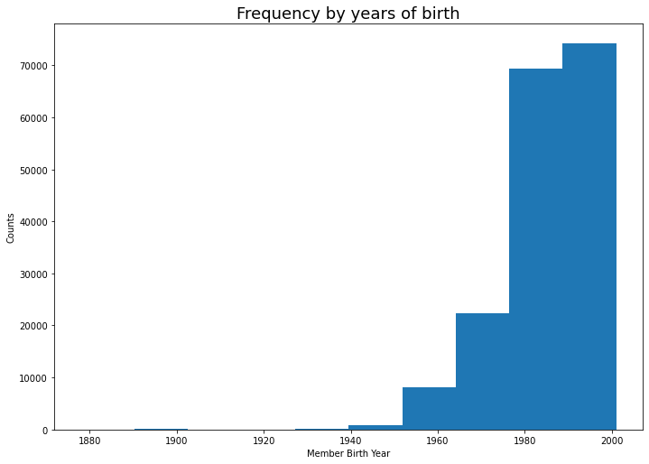

```python
plt.figure(figsize=[ 11.69, 8.27])
plt.hist(data = df_clean, x = 'member_birth_year')
plt.title('Frequency by years of birth', fontsize = 18)
plt.xlabel('Member Birth Year')
plt.ylabel('Counts')
```

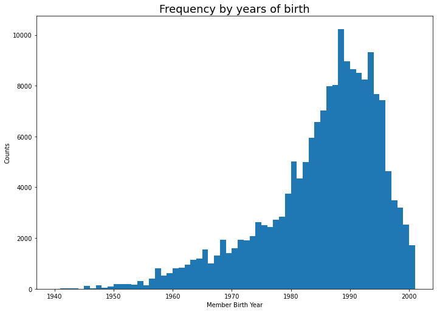

```python
plt.figure(figsize=[ 11.69, 8.27])
bin_edges = np.arange(1940, df_clean['member_birth_year'].max()+1, 1)
sb.distplot(df['member_birth_year'], bins = bin_edges, kde = False,
            hist_kws = {'alpha' : 1})
plt.title('Frequency by years of birth', fontsize = 18)
plt.xlabel('Member Birth Year')
plt.ylabel('Counts')
```

This plot shows the distribution of members by their birth year starting from 1940. The range of most of the members is between 1980 to 2000 and this is from 1985 to 1990.

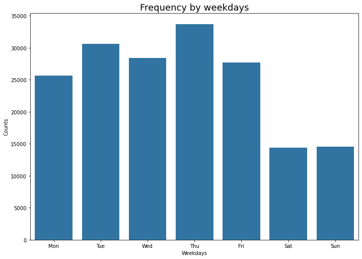

```python
plt.figure(figsize=[ 11.69, 8.27])
base_color = sb.color_palette()[0]
order_days = ['Mon', 'Tue','Wed','Thu','Fri','Sat','Sun']
sb.countplot(data=df_clean, x='start_weekday_char', color=base_color, order = order_days)
plt.title('Frequency by weekdays', fontsize = 18)
plt.xlabel('Weekdays')
plt.ylabel('Counts');
```

The plot shows the distribution between weekdays. The distribution between weekdays shows that Thursday and Tuesday are the peak days and most of the rides are during these days, on the other hand Sunday and Saturday are the least days. We can conclude from this information that most of the members are using it for work so there’s no need to use it on the weekends.

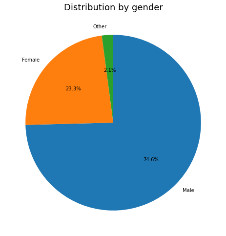

```python
plt.figure(figsize=[ 11.69, 8.27])
sorted_counts = df_clean['member_gender'].value_counts()

plt.pie(sorted_counts, labels = sorted_counts.index, startangle = 90, counterclock = False, autopct='%1.1f%%')
plt.title('Distribution by gender', fontsize = 18)
```

This pie chart shows that 74.6% of the members are men, 23.3% are women and 2.1% identified as “others”.

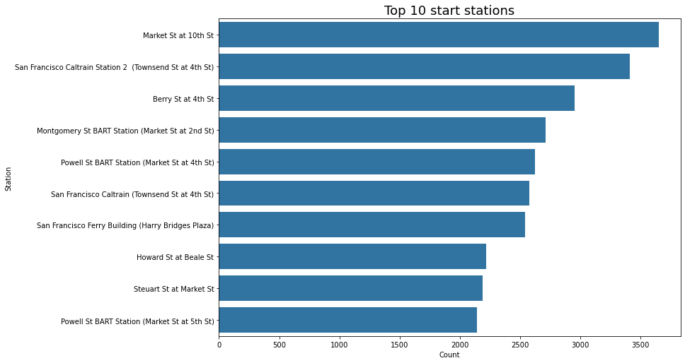

```python
plt.figure(figsize=[ 11.69, 8.27])
sb.countplot(y="start_station_name", data=df_clean, color=base_color,
              order=df_clean.start_station_name.value_counts().iloc[:10].index)
plt.title('Top 10 start stations', fontsize = 18)
plt.xlabel('Count')
plt.ylabel('Station')
```

This shows which stations have most of the traffic for start stations.

> Most of the traffic in these start stations:
> - Market St
> - San Francisco caltrain station 2
> - Berry St

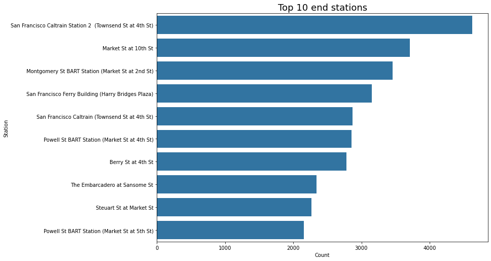

```python
plt.figure(figsize=[ 11.69, 8.27])
sb.countplot(y="end_station_name", data=df_clean, color=base_color,
              order=df_clean.end_station_name.value_counts().iloc[:10].index)
plt.title('Top 10 end stations', fontsize = 18)
plt.xlabel('Count')
plt.ylabel('Station')
```

This shows which stations have most of the traffic for end stations.

> Most of the traffic in these end stations:
> - San Francisco caltrain station 2
> - Market St
> - Montgomery St BART Station

## Bivariate Exploration

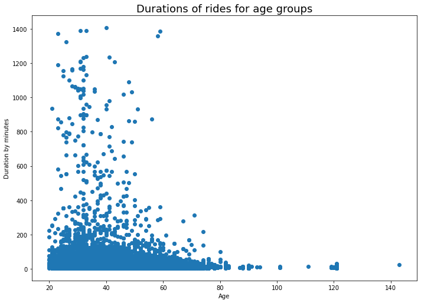

```python
# Scatter plot
plt.figure(figsize=[ 11.69, 8.27])
plt.scatter(data = df_clean, x = 'member_age', y = 'duration_min');
plt.title('Durations of rides for age groups', fontsize = 18)
plt.xlabel('Age')
plt.ylabel('Duration by minutes')
```

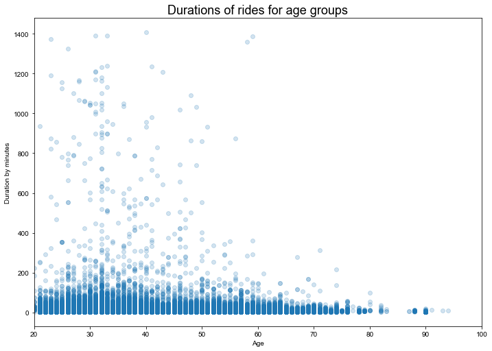

```python
plt.figure(figsize=[ 11.69, 8.27])
plt.scatter(data = df_clean, x = 'member_age', y = 'duration_min', alpha = 0.2);
plt.style.use('seaborn')
plt.title('Durations of rides for age groups', fontsize = 18)
plt.xlabel('Age')
plt.ylabel('Duration by minutes')
plt.xlim(df_clean['member_age'].min(), 100);
```

This plot shows the duration of rides for each age group. The age group 30-40 tends to have more duration for riders.

```python
top_starts = df_clean['bike_id'].value_counts().index[:5]
gobike_df_stations = df_clean.loc[df_clean['bike_id'].isin(top_starts)]
```

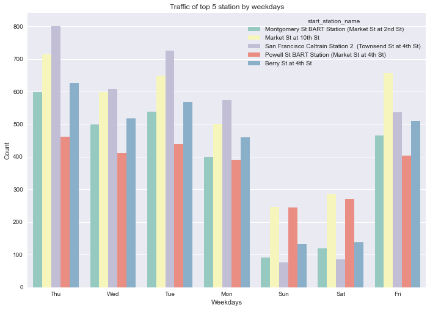

```python
#New dataframe of top 5 stations
names = df_clean['start_station_name'].value_counts().head(5).index.tolist()
df_stations = df_clean[df_clean['start_station_name'].isin(names)]

palette = sb.color_palette('Set3')

#plot the traffic for top 5 stations across weekdays
plt.figure(figsize=[ 11.69, 8.27])
sb.countplot(data = df_stations, x = 'start_weekday_char', hue = 'start_station_name', palette = palette)
plt.title('Traffic of top 5 station by weekdays')
plt.xlabel('Weekdays')
plt.ylabel('Count')
plt.tight_layout;
```

[figure not shown]

```python
#New dataframe of top 5 stations
names = df_clean['start_station_name'].value_counts().head(10).index.tolist()
df_stations = df_clean[df_clean['start_station_name'].isin(names)]

palette = sb.color_palette('Set1', 4)

#plot the traffic for top 5 stations across weekdays
plt.figure(figsize=[ 11.69, 8.27])
sb.countplot(data = df_stations, y = 'start_station_name', hue = 'user_type', palette = palette)
plt.title('Traffic of top 5 station for user type')
plt.xlabel('Count')
plt.ylabel('Station')
plt.tight_layout;
```

This plot shows traffic for the top 10 stations for each user type, as it shows that the increase in either user type doesn’t necessarily mean the increase of the other type. Most of the traffic for subscribers is in Market St and San Francisco Caltrain station 2. For customers, most of the traffic is in the San Francisco Ferry Building.

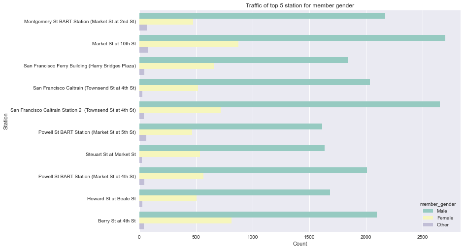

```python
#New dataframe of top 5 stations
names = df_clean['start_station_name'].value_counts().head(10).index.tolist()
df_stations = df_clean[df_clean['start_station_name'].isin(names)]

palette = sb.color_palette('Set3')

#plot the traffic for top 5 stations across weekdays
plt.figure(figsize=[ 11.69, 8.27])
sb.countplot(data = df_stations, y = 'start_station_name', hue = 'member_gender', palette = palette)
plt.title('Traffic of top 5 station for member gender')
plt.xlabel('Count')
plt.ylabel('Station')
plt.tight_layout;
```

This plot shows traffic for the top 10 stations for each gender, for men the most traffic stations are Market St at 10the St and San Francisco Caltrain station 2. For women market St and Berry St at 4th St.

## Multivariate Exploration

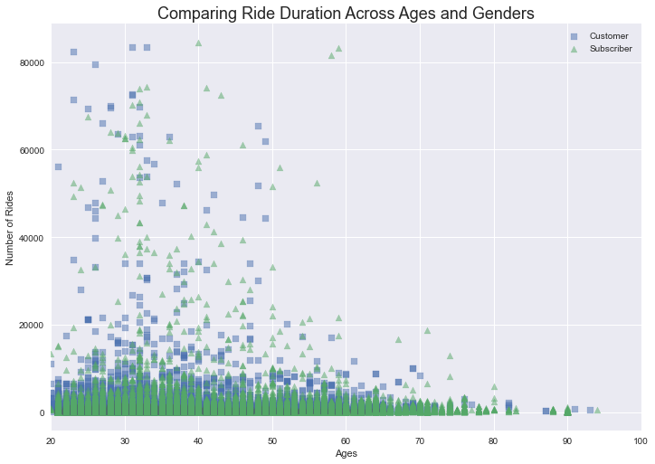

```python
cat_markers = [['Customer', 's'],
               ['Subscriber', '^']]
plt.figure(figsize=[ 11.69, 8.27])
for cat, marker in cat_markers:
    df_cat = df_clean[df_clean['user_type'] == cat]
    plt.scatter(data = df_cat, x = 'member_age', y = 'duration_sec', marker = marker, alpha = .5);
plt.legend(['Customer', 'Subscriber']);
plt.xlim(df_clean['member_age'].min(), 100);
plt.title('Comparing Ride Duration Across Ages and Genders', fontsize = 18);
plt.xlabel('Ages');
plt.ylabel('Number of Rides');
plt.style.use('seaborn')
```

This plot compares the duration of rides across ages and user types. The subscriber type tends to overlap in small durations and the customer type has more durations. Most of the two types are between 20-60 years.

```python
df_clean.to_csv('clean-fordgobike-tripdata.csv')
```

```python
from subprocess import call
call(['python', '-m', 'nbconvert', 'Ford GoBike Exploration.ipynb'])
```

```python
!jupyter nbconvert presentation.ipynb --to slides --post serve --no-input --no-prompt
```

```python
!tar chvfz notebook.tar.gz *
```